# Lab 6 Assignment

Dylan Berneman

2023-05-13

### Question 1

1. Summarize how you would carry out the following steps in time series analysis. You can describe briefly by words, or write down R commands you would use to implement these steps.

• Step 1 Data processing (make the data stationary)

```r
covid <- read.csv("owid-covid-data 2.csv")

covid[(is.na(covid))]<-0

covid <- covid %>%
  group_by(date) %>%
  summarise(across(c(total_cases, new_cases, new_cases_smoothed, total_deaths, new_deaths, new_deaths_smoothed), sum))

covid["Smoothed_New_Case_Fatality_Rate"] = NA

for(i in 1:1225){
  covid$Smoothed_New_Case_Fatality_Rate[i] = covid$new_deaths_smoothed[i] / covid$new_cases_smoothed[i]}

covid <- covid[346:1225,]

Mortality = ts(covid$Smoothed_New_Case_Fatality_Rate)

# check for seasonality
frequency(Mortality)
```

```
## [1] 1
```

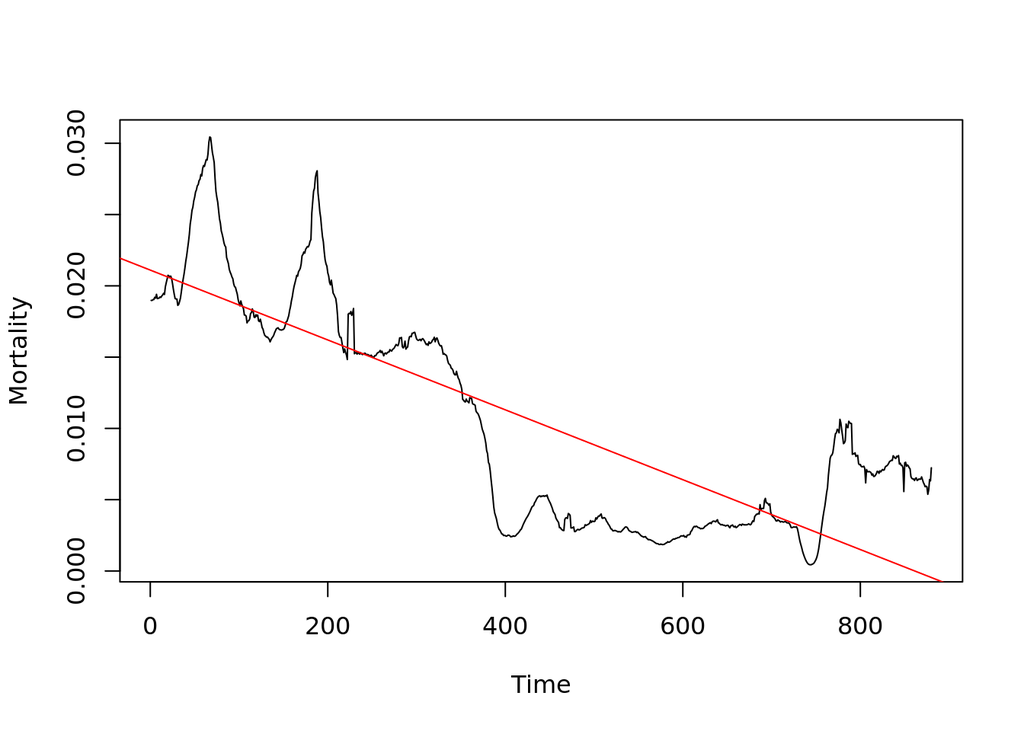

```r
# plot w/ mean line
plot.ts(Mortality)
abline(reg=lm(Mortality~time(Mortality)), col="red")
```

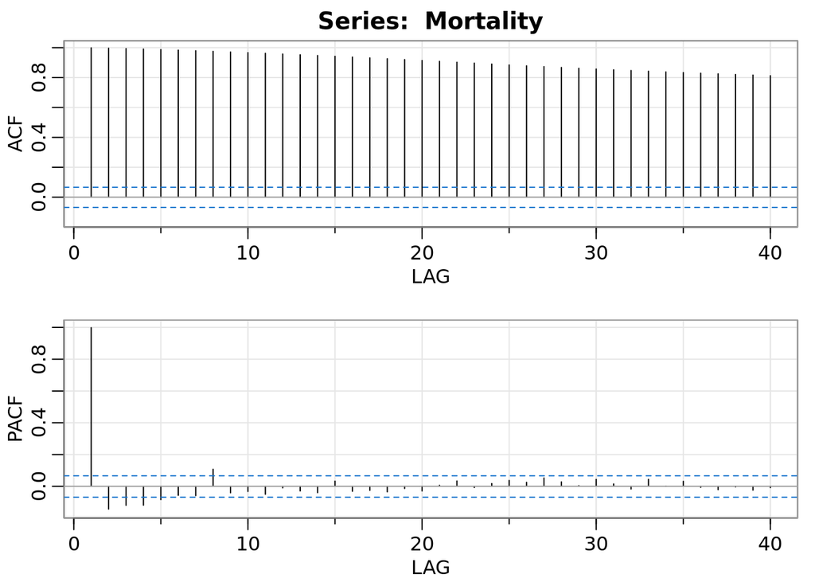

```r
# plot acf
Mortality_acf1 = acf2(Mortality)
```

```r
# get variance
var(Mortality)
```

```
## [1] 6.025961e-05
```

```r
# variance is stable
# just to check for transformations

# square root transform
Mortality.Sqrt = sqrt(Mortality)
# variance is much greater than the original series
var(Mortality.Sqrt)
```

```
## [1] 0.001527589
```

```r
# log transform
Mortality.log = log(Mortality)
# variance is much greater than the original series
var(Mortality.log)
```

```
## [1] 0.8105882
```

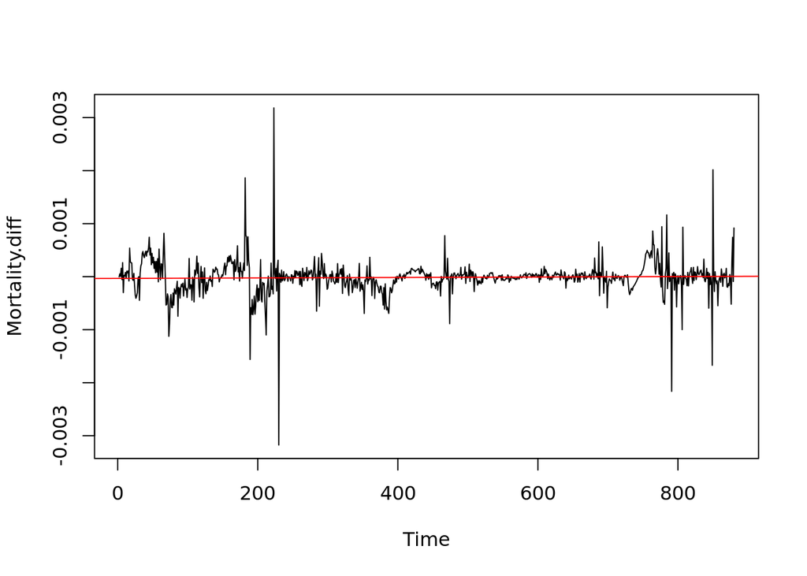

```r
# try differencing
Mortality.diff = diff(Mortality, 1)

# stop once mean is a horizontal line
plot.ts(Mortality.diff)
abline(reg=lm(Mortality.diff~time(Mortality.diff)), col="red")
```

```r
# smaller variance than the original
var(Mortality.diff)
```

```
## [1] 1.019611e-07
```

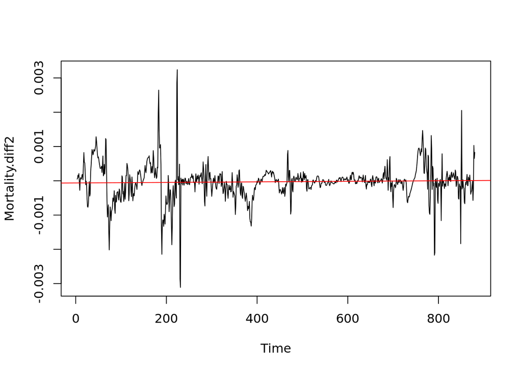

```r
Mortality.diff2 = diff(Mortality, 2)
plot.ts(Mortality.diff2)
abline(reg=lm(Mortality.diff2~time(Mortality.diff2)), col="red")
```

```r
# larger variance than 1st difference
var(Mortality.diff2)
```

```
## [1] 2.529567e-07
```

```r
# Diff = 1
var(Mortality.diff) < var(Mortality.diff2)
```

```
## [1] TRUE
```

```r
# Match ACF to theoretical
Mortality.diff_acf1 = acf2(Mortality.diff)
```

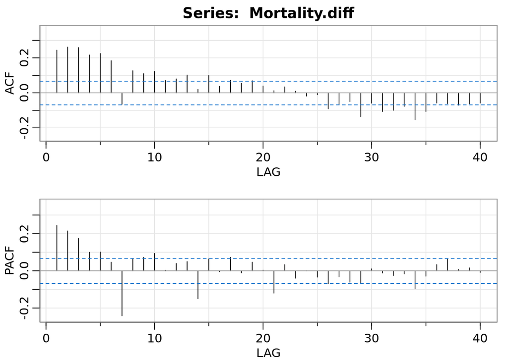

Then match theoretical p/acf to sample p/acf to find p and q

• Step 2 Model identification  
- Find a theoretical stationary model that has similar acf/pacf to the sample

• Step 3 Model estimation  
- Use arima, yw, innovation algorithm, and mle to estimate the model coefficients

• Step 4 Model selection  
- Use AICc to find the model with the lowest value.

• Step 5 Model diagnostics  
- Examine normal Q-Q plot - Ran Shapiro-Wilk test of normality -check sample acf/pacf of residuals resembles WN 95% ci - Portmanteau tests

• Step 6 Data forecast  
- Forecast future observations

2. Review this week’s lab material, Dow Jones Index question part 3) (‘Make the data stationary’). Is differencing once at lag 1 sufficient to make the data stationary? If yes, justify it. If no, try to make it stationary. Please write related R Codes.

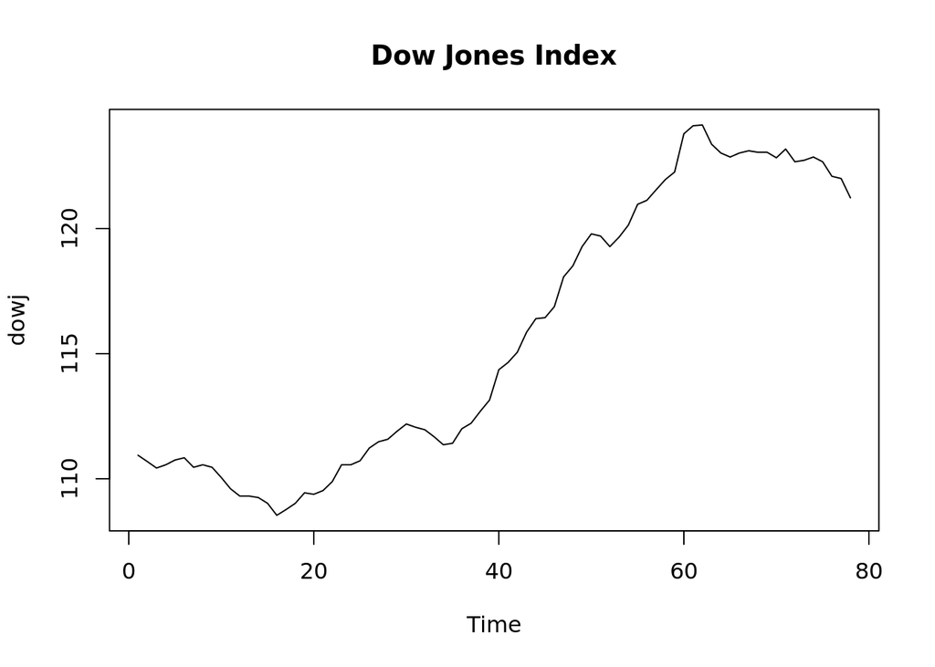

```r
dowj_data <- scan("dowj.txt")
dowj <- ts(dowj_data)
ts.plot(dowj,main = "Dow Jones Index")
```

```r
acf = acf2(dowj)
```

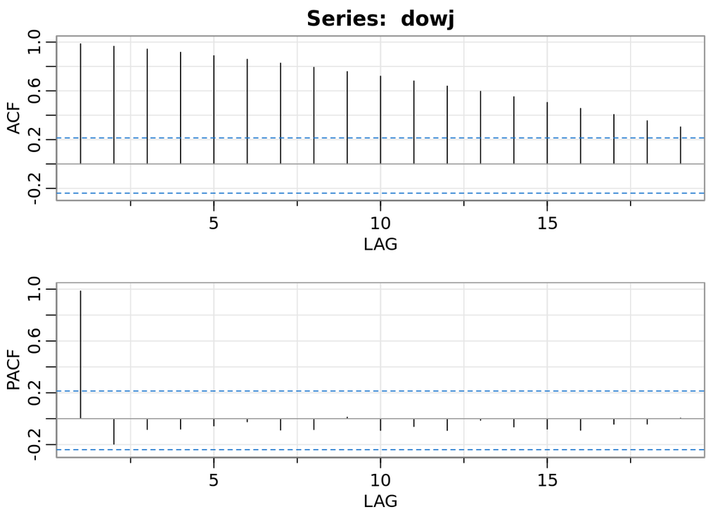

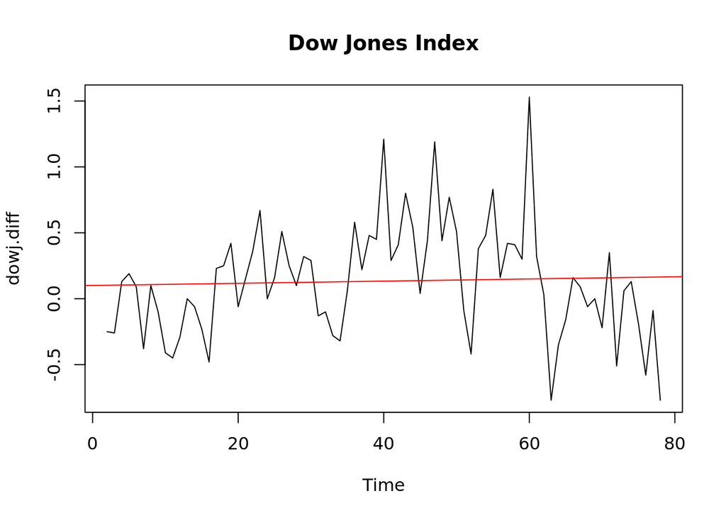

```r
dowj.diff = diff(dowj, 1)
ts.plot(dowj.diff,main = "Dow Jones Index")
abline(reg=lm(dowj.diff~time(dowj.diff)), col="red")
```

```r
acf2 = acf2(dowj.diff)
```

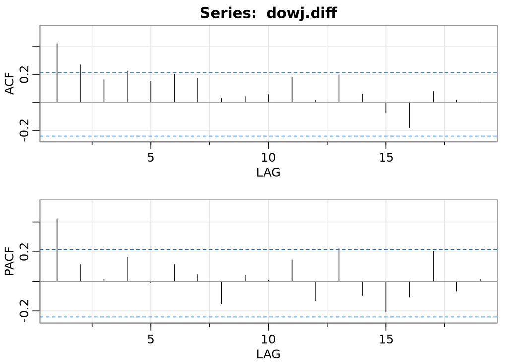

Differencing once at lag 1 is enough to make the time series stationary. As can be seen in the acf and pacf of the differenced time series, a majority of the values at each lag are within the confidence interval.